# EP11-Estadistica

Equipo 4

tbd-07-2026

# Contexto

Para este ejercicio usaremos los datos de medidas anatómicas recolectados por Heinz et al. (2003) que ya hemos utilizado en los ejercicios prácticos anteriores (disponibles en el archivo “EP09 Datos.csv”), con la adición de las variables IMC y EN consideradas en el ejercicio práctico anterior.

# Preguntas

1. Definir la semilla a utilizar, que corresponde a los primeros cinco dígitos del RUN del integrante de mayor edad del equipo.
2. Seleccionar una muestra de 100 personas, asegurando que la mitad tenga estado nutricional “sobrepeso” y la otra mitad “no sobrepeso”.
3. Usando las herramientas del paquete leaps, realizar una búsqueda exhaustiva para seleccionar entre dos y ocho predictores que ayuden a estimar la variable Peso (Weight), obviamente sin considerar las nuevas variables IMC ni EN, y luego utilizar las funciones del paquete caret para construir un modelo de regresión lineal múltiple con los predictores escogidos y evaluarlo usando bootstrapping.
4. Haciendo un poco de investigación sobre el paquete caret, en particular cómo hacer Recursive Feature Elimination (RFE), construir un modelo de regresión lineal múltiple para predecir la variable IMC que incluya entre 10 y 20 predictores, seleccionando el conjunto de variables que maximice R2 y que use cinco repeticiones de validación cruzada de cinco pliegues para evitar el sobreajuste (obviamente no se debe considerar las variables Peso, Estatura ni estado nutricional –Weight, Height, EN respectivamente).
5. Usando RFE, construir un modelo de regresión logística múltiple para la variable EN que incluya el conjunto de predictores, entre dos y seis, que entregue la mejor curva ROC y que utilice validación cruzada dejando uno fuera para evitar el sobreajuste (obviamente no se debe considerar las variables Peso, Estatura –Weight y Height respectivamente– ni IMC).
6. Pronunciarse sobre la confiabilidad y el poder predictivo de los modelos obtenidos.

## 1)

Se fijó la semilla de reproducibilidad y se construyó una muestra balanceada de 100 personas (50 “sobrepeso”, 50 “no sobrepeso”) a partir de los datos indicados.

```r
library(dplyr)
# Cargar los datos
datos <- read.csv2("EP09 Datos.csv")

# Crear las variables IMC y EN
datos <- datos |>
  mutate(IMC = Weight / (Height / 100)^2) |>
  mutate(EN = ifelse(IMC >= 23.2, "sobrepeso", "no sobrepeso")) |>
  mutate(EN = factor(EN, levels = c("no sobrepeso", "sobrepeso")))

# Verificamos los resultados mostrando las primeras filas
head(datos |> select(Weight, Height, IMC, EN))
```

|  | Weight | Height | IMC | EN |
| --- | --- | --- | --- | --- |
| 1 | 65.6 | 174.0 | 21.66733 | no sobrepeso |
| 2 | 71.8 | 175.3 | 23.36472 | sobrepeso |
| 3 | 80.7 | 193.5 | 21.55319 | no sobrepeso |
| 4 | 72.6 | 186.5 | 20.87272 | no sobrepeso |
| 5 | 78.8 | 187.2 | 22.48612 | no sobrepeso |
| 6 | 74.8 | 181.5 | 22.70640 | no sobrepeso |

```r
# Vemos un resumen de la nueva variable dicotómica
cat("\nDistribución del Estado Nutricional (EN):\n")
```

```
##
## Distribución del Estado Nutricional (EN):
```

```r
summary(datos$EN)
```

```
## no sobrepeso    sobrepeso
##          256          251
```

```r
# Semilla para asegurar reproducibilidad
set.seed(21097)
```

## 2)

```r
# 2. Tomar las muestras indicando que provienen de 'datos'
muestra_sobrepeso <- datos |>
  filter(EN == "sobrepeso") |>
  slice_sample(n = 50)

muestra_no_sobrepeso <- datos |>
  filter(EN == "no sobrepeso") |>
  slice_sample(n = 50)

# 3. Unirlas en un solo data.frame
muestra_total <- bind_rows(muestra_sobrepeso, muestra_no_sobrepeso)
```

## 3)

Para estimar el Peso se buscó de forma exhaustiva con leaps el subconjunto de 2 a 8 predictores con menor BIC, y se evaluó el modelo resultante con bootstrapping para obtener una estimación más robusta de su capacidad predictiva.

```r
library(leaps)
library(caret)
# Conjunto de predictores candidatos para el modelo de Peso (Weight):
# se excluyen IMC y EN, tal como exige el enunciado
datos_weight <- muestra_total |>
  select(-IMC, -EN)

# Búsqueda exhaustiva (leaps)
set.seed(21097)
busqueda_peso <- regsubsets(Weight ~ ., data = datos_weight,
                             nbest = 1, nvmax = 8,
                             method = "exhaustive")

resumen_busqueda <- summary(busqueda_peso)

cat("BIC según cantidad de predictores (1 a 8):\n")
```

```
## BIC según cantidad de predictores (1 a 8):
```

```r
print(data.frame(n_predictores = 1:length(resumen_busqueda$bic),
                  BIC = resumen_busqueda$bic))
```

```
##   n_predictores       BIC
## 1             1 -166.2296
## 2             2 -225.9719
## 3             3 -275.3548
## 4             4 -302.0482
## 5             5 -309.0435
## 6             6 -315.4665
## 7             7 -321.0258
## 8             8 -321.1351
```

```r
# Se escoge, entre los modelos de 2 a 8 predictores, el de menor BIC
bic_validos  <- resumen_busqueda$bic[2:8]
mejor_tamano <- which.min(bic_validos) + 1

cat("\nCantidad de predictores seleccionada:", mejor_tamano, "\n")
```

```
##
## Cantidad de predictores seleccionada: 8
```

```r
coefs_mejor_modelo <- coef(busqueda_peso, id = mejor_tamano)
predictores_weight <- names(coefs_mejor_modelo)[-1]

cat("\nPredictores seleccionados para estimar el Peso:\n")
```

```
##
## Predictores seleccionados para estimar el Peso:
```

```r
print(predictores_weight)
```

```
## [1] "Knees.diameter" "Chest.Girth"    "Waist.Girth"    "Hip.Girth"
## [5] "Thigh.Girth"    "Knee.Girth"     "Age"            "Height"
```

```r
# Modelo de RLM final, evaluado con bootstrapping (caret)
formula_weight <- as.formula(paste("Weight ~", paste(predictores_weight, collapse = " + ")))

set.seed(21097)
control_boot <- trainControl(method = "boot", number = 999)

modelo_weight_boot <- train(formula_weight, data = datos_weight,
                             method = "lm",
                             trControl = control_boot)

cat("\nModelo de RLM para Peso, evaluado con bootstrapping (999 repeticiones):\n")
```

```
##
## Modelo de RLM para Peso, evaluado con bootstrapping (999 repeticiones):
```

```r
print(modelo_weight_boot)
```

```
## Linear Regression
##
## 100 samples
##   8 predictor
##
## No pre-processing
## Resampling: Bootstrapped (999 reps)
## Summary of sample sizes: 100, 100, 100, 100, 100, 100, ...
## Resampling results:
##
##   RMSE      Rsquared   MAE
##   2.306187  0.9672798  1.820267
##
## Tuning parameter 'intercept' was held constant at a value of TRUE
```

```r
print(summary(modelo_weight_boot$finalModel))
```

```
##
## Call:
## lm(formula = .outcome ~ ., data = dat)
##
## Residuals:
##     Min      1Q  Median      3Q     Max
## -4.1915 -1.4494  0.0493  1.1996  6.9463
##
## Coefficients:
##                  Estimate Std. Error t value Pr(>|t|)
## (Intercept)    -124.97286    5.55199 -22.510  < 2e-16 ***
## Knees.diameter    0.88742    0.28047   3.164  0.00212 **
## Chest.Girth       0.41313    0.05548   7.446 5.29e-11 ***
## Waist.Girth       0.34179    0.05509   6.204 1.60e-08 ***
## Hip.Girth         0.28766    0.08497   3.385  0.00105 **
## Thigh.Girth       0.30363    0.11069   2.743  0.00733 **
## Knee.Girth        0.36310    0.17324   2.096  0.03886 *
## Age              -0.07901    0.02407  -3.282  0.00146 **
## Height            0.33259    0.03690   9.014 2.95e-14 ***
## ---
## Signif. codes:  0 '***' 0.001 '**' 0.01 '*' 0.05 '.' 0.1 ' ' 1
##
## Residual standard error: 2.102 on 91 degrees of freedom
## Multiple R-squared:  0.9734, Adjusted R-squared:  0.971
## F-statistic: 415.8 on 8 and 91 DF,  p-value: < 2.2e-16
```

## 4)

Para predecir el IMC se usó Recursive Feature Elimination (RFE) de caret, buscando entre 10 y 20 predictores (sin Weight, Height ni EN) que maximizaran el R², con validación cruzada de 5 pliegues y 5 repeticiones para evitar el sobreajuste.

```r
library(caret)

# Predictores candidatos: se excluyen Weight, Height y EN (Weight/Height
# determinan directamente el IMC, y EN se deriva del IMC)
predictores_imc <- muestra_total |>
  select(-Weight, -Height, -EN, -IMC)

respuesta_imc <- muestra_total$IMC

# Control de RFE: 5 repeticiones de validación cruzada de 5 pliegues
set.seed(21097)
control_rfe_imc <- rfeControl(
  functions = lmFuncs,
  method    = "repeatedcv",
  number    = 5,
  repeats   = 5,
  verbose   = FALSE
)

# Búsqueda RFE entre 10 y 20 predictores, maximizando R2
modelo_rfe_imc <- rfe(
  x          = predictores_imc,
  y          = respuesta_imc,
  sizes      = 10:20,
  rfeControl = control_rfe_imc,
  metric     = "Rsquared"
)

cat("Resultado de la búsqueda RFE para predecir IMC:\n")
```

```
## Resultado de la búsqueda RFE para predecir IMC:
```

```r
print(modelo_rfe_imc)
```

```
##
## Recursive feature selection
##
## Outer resampling method: Cross-Validated (5 fold, repeated 5 times)
##
## Resampling performance over subset size:
##
##  Variables  RMSE Rsquared    MAE RMSESD RsquaredSD  MAESD Selected
##         10 1.390   0.7749 1.1495 0.4330    0.15103 0.3576
##         11 1.254   0.8172 1.0280 0.3460    0.10971 0.2957
##         12 1.135   0.8533 0.9357 0.2415    0.06667 0.2049
##         13 1.081   0.8675 0.8928 0.1925    0.05576 0.1684
##         14 1.056   0.8722 0.8698 0.1739    0.04920 0.1620        *
##         15 1.063   0.8707 0.8775 0.1650    0.04869 0.1543
##         16 1.064   0.8708 0.8765 0.1642    0.04924 0.1506
##         17 1.077   0.8675 0.8873 0.1745    0.05303 0.1591
##         18 1.080   0.8672 0.8913 0.1724    0.05291 0.1596
##         19 1.088   0.8659 0.8919 0.1720    0.05392 0.1579
##         20 1.096   0.8645 0.8991 0.1726    0.05384 0.1599
##         23 1.101   0.8640 0.8999 0.1759    0.05374 0.1629
##
## The top 5 variables (out of 14):
##    Gender, Knees.diameter, Wrist.Minimum.Girth, Chest.diameter, Wrists.diameter
```

```r
predictores_seleccionados_imc <- predictors(modelo_rfe_imc)
cat("\nPredictores seleccionados (", length(predictores_seleccionados_imc),
    " en total):\n", sep = "")
```

```
##
## Predictores seleccionados (14 en total):
```

```r
print(predictores_seleccionados_imc)
```

```
##  [1] "Gender"                  "Knees.diameter"
##  [3] "Wrist.Minimum.Girth"     "Chest.diameter"
##  [5] "Wrists.diameter"         "Bitrochanteric.diameter"
##  [7] "Forearm.Girth"           "Elbows.diameter"
##  [9] "Bicep.Girth"             "Biacromial.diameter"
## [11] "Hip.Girth"               "Waist.Girth"
## [13] "Knee.Girth"              "Ankles.diameter"
```

```r
modelo_imc_final <- modelo_rfe_imc$fit
cat("\nModelo de RLM final para IMC:\n")
```

```
##
## Modelo de RLM final para IMC:
```

```r
print(summary(modelo_imc_final))
```

```
##
## Call:
## lm(formula = y ~ ., data = tmp)
##
## Residuals:
##      Min       1Q   Median       3Q      Max
## -2.01992 -0.62002 -0.07596  0.66017  1.87285
##
## Coefficients:
##                         Estimate Std. Error t value Pr(>|t|)
## (Intercept)             -5.55771    2.38699  -2.328 0.022269 *
## Gender                  -1.08191    0.49727  -2.176 0.032354 *
## Knees.diameter           0.43984    0.15202   2.893 0.004840 **
## Wrist.Minimum.Girth     -0.35208    0.19179  -1.836 0.069885 .
## Chest.diameter           0.25741    0.07291   3.530 0.000673 ***
## Wrists.diameter         -0.33852    0.20190  -1.677 0.097285 .
## Bitrochanteric.diameter -0.27567    0.07847  -3.513 0.000712 ***
## Forearm.Girth            0.18246    0.13273   1.375 0.172847
## Elbows.diameter         -0.20372    0.17723  -1.149 0.253593
## Bicep.Girth              0.20512    0.07953   2.579 0.011628 *
## Biacromial.diameter     -0.18177    0.05455  -3.332 0.001278 **
## Hip.Girth                0.22245    0.03768   5.903 7.10e-08 ***
## Waist.Girth              0.15137    0.02051   7.381 9.79e-11 ***
## Knee.Girth              -0.09773    0.06979  -1.400 0.165063
## Ankles.diameter          0.08084    0.14601   0.554 0.581260
## ---
## Signif. codes:  0 '***' 0.001 '**' 0.01 '*' 0.05 '.' 0.1 ' ' 1
##
## Residual standard error: 0.9247 on 85 degrees of freedom
## Multiple R-squared:  0.9145, Adjusted R-squared:  0.9004
## F-statistic: 64.92 on 14 and 85 DF,  p-value: < 2.2e-16
```

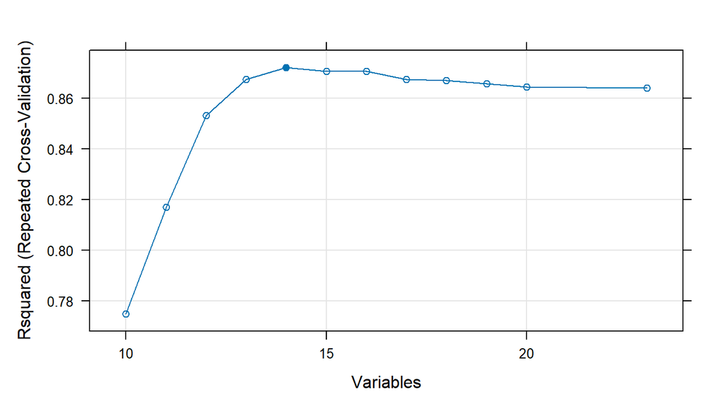

```r
plot(modelo_rfe_imc, type = c("g", "o"))
```

## 5)

Para predecir el estado nutricional (EN) se usó RFE de caret con regresión logística, buscando entre 2 y 6 predictores (sin Weight, Height ni IMC) que maximizaran la curva ROC, con validación cruzada dejando uno fuera (LOOCV) para evitar el sobreajuste.

```r
library(caret)
library(pROC)
# Preparar datos: excluir Weight, Height e IMC como indica el enunciado
predictores_en <- muestra_total |>
  select(-Weight, -Height, -IMC, -EN)

respuesta_en <- muestra_total$EN

# Los niveles del factor deben ser nombres válidos en R para que
# twoClassSummary de caret funcione correctamente
levels(respuesta_en) <- make.names(levels(respuesta_en))

# Configurar funciones de regresión logística para optimizar ROC
lr_funcs <- lrFuncs
lr_funcs$summary <- twoClassSummary

# Control RFE con validación cruzada dejando uno fuera (LOOCV)
set.seed(21097)
control_rfe_en <- rfeControl(
  functions = lr_funcs,
  method    = "LOOCV",
  verbose   = FALSE
)

# Ejecutar RFE buscando entre 2 y 6 predictores, maximizando ROC
modelo_rfe_en <- rfe(
  x          = predictores_en,
  y          = respuesta_en,
  sizes      = 2:6,
  rfeControl = control_rfe_en,
  metric     = "ROC"
)
cat("Resultado de la búsqueda RFE para predecir EN:\n")
```

```
## Resultado de la búsqueda RFE para predecir EN:
```

```r
print(modelo_rfe_en)
```

```
##
## Recursive feature selection
##
## Outer resampling method: Leave-One-Out Cross-Validation
##
## Resampling performance over subset size:
##
##  Variables    ROC Sens Spec Selected
##          2 0.7684 0.68 0.64
##          3 0.7184 0.62 0.58
##          4 0.7500 0.66 0.62
##          5 0.8900 0.84 0.78
##          6 0.9088 0.80 0.82        *
##         23 0.8152 0.80 0.76
##
## The top 5 variables (out of 6):
##    Knee.Girth, Bitrochanteric.diameter, Age, Forearm.Girth, Thigh.Girth
```

```r
predictores_seleccionados_en <- predictors(modelo_rfe_en)
cat("\nPredictores seleccionados (", length(predictores_seleccionados_en),
    " en total):\n", sep = "")
```

```
##
## Predictores seleccionados (6 en total):
```

```r
print(predictores_seleccionados_en)
```

```
## [1] "Knee.Girth"              "Bitrochanteric.diameter"
## [3] "Age"                     "Forearm.Girth"
## [5] "Thigh.Girth"             "Chest.depth"
```

```r
cat("\nModelo de regresión logística final para EN:\n")
```

```
##
## Modelo de regresión logística final para EN:
```

```r
print(summary(modelo_rfe_en$fit))
```

```
##
## Call:
## glm(formula = Class ~ ., family = "binomial", data = tmp)
##
## Coefficients:
##                          Estimate Std. Error z value Pr(>|z|)
## (Intercept)             -61.17560   15.21313  -4.021 5.79e-05 ***
## Knee.Girth               -0.57102    0.35341  -1.616 0.106152
## Bitrochanteric.diameter  -0.74032    0.29450  -2.514 0.011942 *
## Age                       0.12429    0.04749   2.617 0.008858 **
## Forearm.Girth             1.19680    0.37173   3.220 0.001284 **
## Thigh.Girth               1.09056    0.28226   3.864 0.000112 ***
## Chest.depth               0.46377    0.26126   1.775 0.075879 .
## ---
## Signif. codes:  0 '***' 0.001 '**' 0.01 '*' 0.05 '.' 0.1 ' ' 1
##
## (Dispersion parameter for binomial family taken to be 1)
##
##     Null deviance: 138.629  on 99  degrees of freedom
## Residual deviance:  46.179  on 93  degrees of freedom
## AIC: 60.179
##
## Number of Fisher Scoring iterations: 7
```

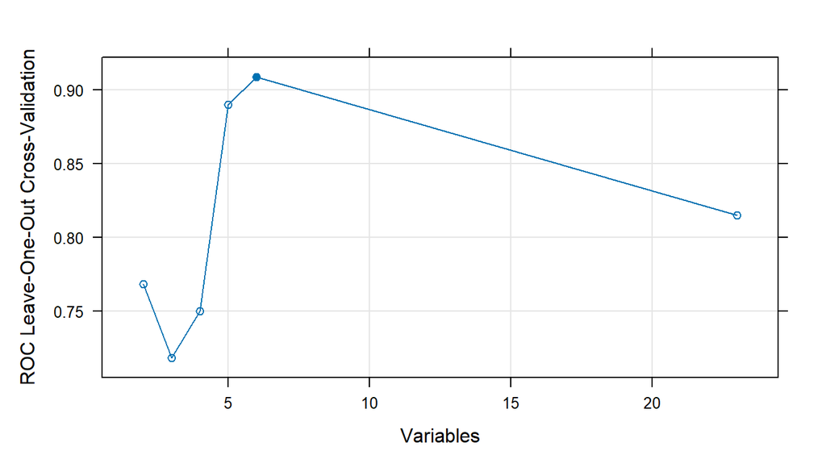

```r
# Gráfico del rendimiento ROC por número de predictores
plot(modelo_rfe_en, type = c("g", "o"))
```

## 6)

Para evaluar la confiabilidad y el poder predictivo de los tres modelos construidos, se examinan las métricas de validación obtenidas con las técnicas de remuestreo empleadas, se verifican las condiciones de los modelos de regresión lineal múltiple y se analiza la curva ROC del modelo logístico.

### Resumen de métricas de validación

```r
library(car)
# --- Modelo de Peso (Pregunta 3) ---
metricas_peso <- modelo_weight_boot$results
cat("--- Modelo de Peso (Bootstrapping, 999 repeticiones) ---\n")
```

```
## --- Modelo de Peso (Bootstrapping, 999 repeticiones) ---
```

```r
cat(sprintf("  R²   = %.4f\n", metricas_peso$Rsquared))
```

```
##   R²   = 0.9673
```

```r
cat(sprintf("  RMSE = %.4f kg\n", metricas_peso$RMSE))
```

```
##   RMSE = 2.3062 kg
```

```r
cat(sprintf("  MAE  = %.4f kg\n", metricas_peso$MAE))
```

```
##   MAE  = 1.8203 kg
```

```r
# --- Modelo de IMC (Pregunta 4) ---
mejor_imc <- modelo_rfe_imc$results[
  modelo_rfe_imc$results$Variables == modelo_rfe_imc$bestSubset, ]
cat("\n--- Modelo de IMC (RFE, 5x5 Validación Cruzada) ---\n")
```

```
##
## --- Modelo de IMC (RFE, 5x5 Validación Cruzada) ---
```

```r
cat(sprintf("  R²   = %.4f\n", mejor_imc$Rsquared))
```

```
##   R²   = 0.8722
```

```r
cat(sprintf("  RMSE = %.4f kg/m²\n", mejor_imc$RMSE))
```

```
##   RMSE = 1.0563 kg/m²
```

```r
cat(sprintf("  MAE  = %.4f kg/m²\n", mejor_imc$MAE))
```

```
##   MAE  = 0.8698 kg/m²
```

```r
cat(sprintf("  Predictores seleccionados: %d\n", mejor_imc$Variables))
```

```
##   Predictores seleccionados: 14
```

```r
# --- Modelo de EN (Pregunta 5) ---
mejor_en <- modelo_rfe_en$results[
  modelo_rfe_en$results$Variables == modelo_rfe_en$bestSubset, ]
cat("\n--- Modelo de EN (RFE, LOOCV) ---\n")
```

```
##
## --- Modelo de EN (RFE, LOOCV) ---
```

```r
cat(sprintf("  AUC-ROC       = %.4f\n", mejor_en$ROC))
```

```
##   AUC-ROC       = 0.9088
```

```r
cat(sprintf("  Sensibilidad  = %.4f\n", mejor_en$Sens))
```

```
##   Sensibilidad  = 0.8000
```

```r
cat(sprintf("  Especificidad = %.4f\n", mejor_en$Spec))
```

```
##   Especificidad = 0.8200
```

```r
cat(sprintf("  Predictores seleccionados: %d\n", mejor_en$Variables))
```

```
##   Predictores seleccionados: 6
```

### Diagnósticos del modelo de Peso (Pregunta 3)

1. La variable de salida “Weight” corresponde a una medida física, siendo una variable cuantitativa continua que cuenta con escala de razón.
2. Las 8 variables predictoras del modelo RLM: “Knees.diameter”, “Chest.Girth”, “Waist.Girth”, “Hip.Girth”, “Thigh.Girth”, “Knee.Girth”, “Age”, “Height”, son medidas de carácter cuantitativo, ya que se pueden medir y expresar numéricamente.
3. Se comprueba que los predictores presentan variabilidad (varianza distinta de cero), por medio del siguiente script:

```r
# Definir un vector con los nombres de las columnas
columnas_objetivo <- c("Knees.diameter", "Chest.Girth", "Waist.Girth", "Hip.Girth", "Thigh.Girth", "Knee.Girth", "Age", "Height")

# Aplicar la función var() a esas columnas específicas usando sapply
sapply(datos_weight[columnas_objetivo], function(x) var(x, na.rm = TRUE))
```

```
## Knees.diameter    Chest.Girth    Waist.Girth      Hip.Girth    Thigh.Girth
##       1.575580      90.725196     107.811647      32.044722      15.932011
##     Knee.Girth            Age         Height
##       5.410683      98.835859      82.688804
```

4. Cada predictor debe tener relación lineal con la respuesta

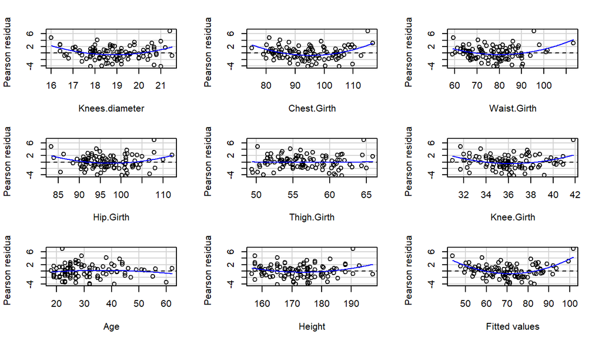

```
##                Test stat Pr(>|Test stat|)
## Knees.diameter    3.4232        0.0009333 ***
## Chest.Girth       4.0542        0.0001067 ***
## Waist.Girth       3.4517        0.0008505 ***
## Hip.Girth         2.5269        0.0132527 *
## Thigh.Girth       0.0587        0.9533074
## Knee.Girth        3.1019        0.0025682 **
## Age              -0.8616        0.3911850
## Height            2.2693        0.0256390 *
## Tukey test        5.8078         6.33e-09 ***
## ---
## Signif. codes:  0 '***' 0.001 '**' 0.01 '*' 0.05 '.' 0.1 ' ' 1
```

```r
library(car)

# Construir la fórmula de manera dinámica con los predictores seleccionados
formula_weight <- as.formula(paste("Weight ~", paste(predictores_weight, collapse = " + ")))

# Ajustar el modelo de forma nativa en R
modelo_nativo_weight <- lm(formula_weight, data = datos_weight)

residualPlots(modelo_nativo_weight)
```

Las pruebas obtenidas, a partir de la función residualPlots() del paquete car sugiere que varios de los predictores utilizados por el modelo no cumplen con el supuesto de linealidad, por lo que se debe tener especial cuidado respecto a las predicciones del modelo, ya que operaciones como obtener los coeficientes del modelo de regresión podría entregar datos sesgados.

5. Distribución de los residuos cercana a la normal centrada en cero

```r
modelo_peso_final <- modelo_weight_boot$finalModel

# Normalidad de residuos
cat("Prueba de Shapiro-Wilk para normalidad de residuos:\n")
```

```
## Prueba de Shapiro-Wilk para normalidad de residuos:
```

```r
sw_peso <- shapiro.test(residuals(modelo_peso_final))
print(sw_peso)
```

```
##
##  Shapiro-Wilk normality test
##
## data:  residuals(modelo_peso_final)
## W = 0.98585, p-value = 0.3652
```

Con un nivel de confianza del 95% es posible concluir que el modelo si cumple con el supuesto de normalidad de los residuos.

6. Homocedasticidad

```r
ncvTest(modelo_peso_final)
```

```
## Non-constant Variance Score Test
## Variance formula: ~ fitted.values
## Chisquare = 5.328206, Df = 1, p = 0.020983
```

Existe evidencia estadística (95% de confianza) para afirmar que no se cumple el supuesto de homocedasticidad en este modelo para predecir el peso. Esto significa que los errores de predicción presentan variabilidad no constante (heterocedasticidad), lo que puede afectar la precisión y los errores estándar de los coeficientes estimados por mínimos cuadrados ordinarios (MCO)

7. Residuos independientes entre sí

```r
durbinWatsonTest(modelo_peso_final)
```

```
##  lag Autocorrelation D-W Statistic p-value
##    1      -0.3568966      2.677639   0.002
##  Alternative hypothesis: rho != 0
```

Existe evidencia estadística suficiente para afirmar que no se cumple el supuesto de independencia de los residuos.

8. Prueba de multicolinealidad mediante el factor de inflación de varianza:

```r
# Multicolinealidad
cat("\nFactores de inflación de varianza (VIF):\n")
```

```
##
## Factores de inflación de varianza (VIF):
```

```r
vif_peso <- vif(modelo_peso_final)
print(vif_peso)
```

```
## Knees.diameter    Chest.Girth    Waist.Girth      Hip.Girth    Thigh.Girth
##       2.778432       6.260903       7.335394       5.186760       4.376129
##     Knee.Girth            Age         Height
##       3.640147       1.283780       2.523465
```

```r
cat("\nPredictores con VIF > 5:", sum(vif_peso > 5),
    "de", length(vif_peso), "\n")
```

```
##
## Predictores con VIF > 5: 3 de 8
```

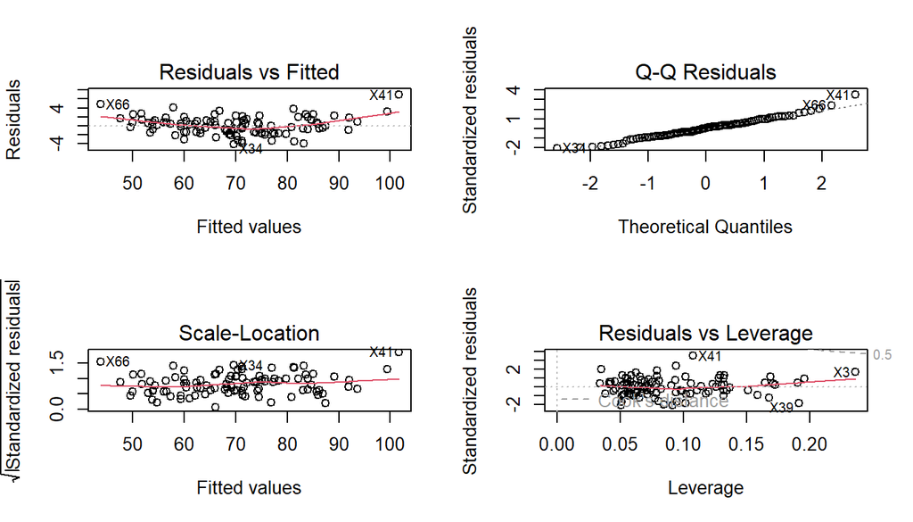

```r
# Gráficos diagnósticos
par(mfrow = c(2, 2))
plot(modelo_peso_final)
```

```r
par(mfrow = c(1, 1))
```

Se concluye que el modelo presenta problemas moderados de multicolinealidad. COmo los datos representan medidas de perímetros y dimensiones corporales humanas (como el contorno de pecho, cintura y cadera), es esperable que estas variables estén fuertemente correlacionadas entre sí

9. Gráfica de influencia

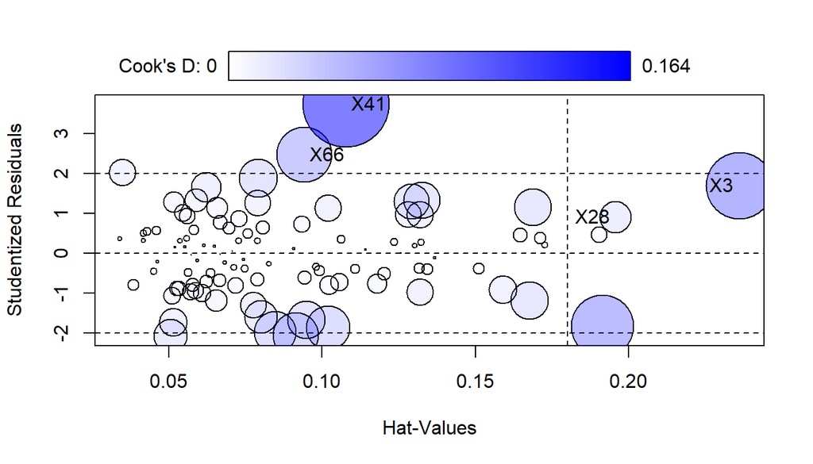

|  | StudRes | Hat | CookD |
| --- | --- | --- | --- |
| X3 | 1.6962592 | 0.23615504 | 0.09684245 |
| X28 | 0.9079415 | 0.19575072 | 0.02233701 |
| X41 | 3.7407720 | 0.10774490 | 0.16429463 |
| X66 | 2.4671008 | 0.09418175 | 0.06659408 |

```r
influencePlot(modelo_peso_final)
```

### Diagnósticos del modelo de IMC (Pregunta 4)

1. La variable de salida “IMC” es una variable derivada de dos medidas físicas “Weight” y “Height”, siendo una variable cuantitativa continua que cuenta con escala de razón.
2. Las 14 variables predictoras del modelo RLM: “Gender”, “Knees.diameter”, “Wrist.Minimum.Girth”, “Chest.diameter”, “Wrists.diameter”, “Bitrochanteric.diameter”, “Forearm.Girth”, “Elbows.diameter”, “Bicep.Girth”, “Biacromial.diameter”, “Hip.Girth”, “Waist.Girth”, “Knee.Girth”, “Ankles.diameter” son medidas de carácter cuantitativo, ya que se pueden medir y expresar numéricamente, excepto “Gender” el cual se maneja como una variable indicadora.
3. Se comprueba que los predictores tienen variabilidad (varianza distinta de cero), por medio del siguiente script:

```r
# Definir un vector con los nombres de las columnas
columnas_objetivo <- c("Gender", "Knees.diameter", "Wrist.Minimum.Girth", "Chest.diameter", "Wrists.diameter", "Bitrochanteric.diameter", "Forearm.Girth", "Elbows.diameter", "Bicep.Girth", "Biacromial.diameter", "Hip.Girth", "Waist.Girth", "Knee.Girth", "Ankles.diameter")

# Aplicar la función var() a esas columnas específicas usando sapply
sapply(muestra_total[columnas_objetivo], function(x) var(x, na.rm = TRUE))
```

```
##                  Gender          Knees.diameter     Wrist.Minimum.Girth
##               0.2516162               1.5755798               1.8556071
##          Chest.diameter         Wrists.diameter Bitrochanteric.diameter
##               6.5637939               1.0740364               3.8702010
##           Forearm.Girth         Elbows.diameter             Bicep.Girth
##               7.4923273               1.9371909              16.4756727
##     Biacromial.diameter               Hip.Girth             Waist.Girth
##               9.1805768              32.0447222             107.8116475
##              Knee.Girth         Ankles.diameter
##               5.4106828               1.4497162
```

4. Cada predictor debe tener relación lineal con la respuesta

```r
library(car)

# Obtener los nombres de las variables elegidas por RFE
predictores_imc_seleccionados <- predictors(modelo_rfe_imc)

# Ver cuáles fueron en la consola
print(predictores_imc_seleccionados)
```

```
##  [1] "Gender"                  "Knees.diameter"
##  [3] "Wrist.Minimum.Girth"     "Chest.diameter"
##  [5] "Wrists.diameter"         "Bitrochanteric.diameter"
##  [7] "Forearm.Girth"           "Elbows.diameter"
##  [9] "Bicep.Girth"             "Biacromial.diameter"
## [11] "Hip.Girth"               "Waist.Girth"
## [13] "Knee.Girth"              "Ankles.diameter"
```

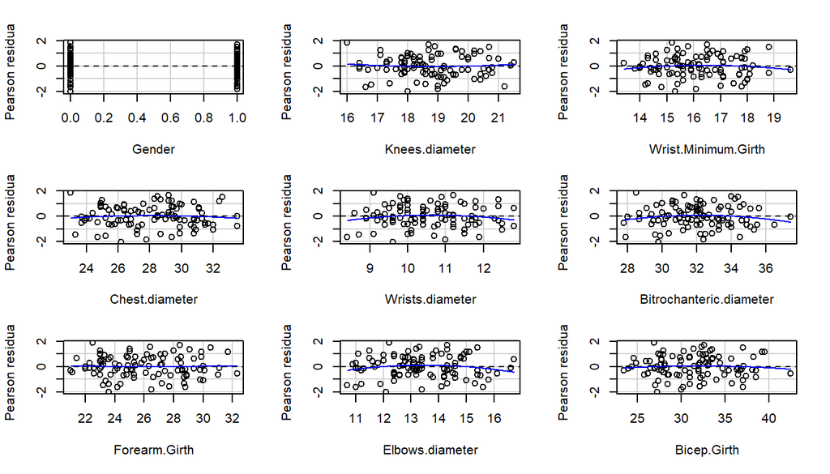

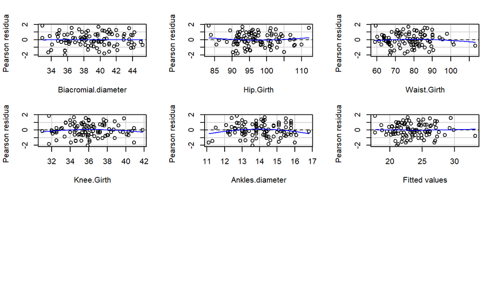

```
##                         Test stat Pr(>|Test stat|)
## Gender                    -0.1832           0.8551
## Knees.diameter             0.5168           0.6066
## Wrist.Minimum.Girth       -0.8146           0.4176
## Chest.diameter            -0.5227           0.6026
## Wrists.diameter           -1.2283           0.2228
## Bitrochanteric.diameter   -1.1652           0.2473
## Forearm.Girth              0.1756           0.8610
## Elbows.diameter           -1.3890           0.1685
## Bicep.Girth               -0.5329           0.5955
## Biacromial.diameter       -0.1155           0.9083
## Hip.Girth                  0.7881           0.4328
## Waist.Girth               -0.6561           0.5135
## Knee.Girth                -0.8595           0.3925
## Ankles.diameter           -1.5620           0.1220
## Tukey test                 0.2063           0.8366
```

```r
# Crear la fórmula dinámica con los predictores seleccionados por RFE
formula_imc_nativa <- as.formula(paste("IMC ~", paste(predictores_imc_seleccionados, collapse = " + ")))

# Ajustar el modelo de forma nativa en R
modelo_nativo_imc <- lm(formula_imc_nativa, data = muestra_total)

# Dividir el espacio gráfico en una cuadrícula (ej: 3 filas y 4 columnas)
par(mfrow = c(2, 3))

# Ejecutar los gráficos de residuos
residualPlots(modelo_nativo_imc)
```

```r
# (Opcional) Restaurar la ventana gráfica a su estado normal de 1x1 al terminar
par(mfrow = c(1, 1))
```

Se observa en los gráficos de residuos que gran parte de los predictores se encuentran ajustados a la recta en 0, lo que nos habla de que la linealidad podría cumplirse, excepto en algunos casos “Ankles.diameter” donde se puede ver una curva un poco más pronunciada.

5. Distribución de los residuos cercana a la normal centrada en cero

```r
# Normalidad de residuos
cat("Prueba de Shapiro-Wilk para normalidad de residuos:\n")
```

```
## Prueba de Shapiro-Wilk para normalidad de residuos:
```

```r
sw_imc <- shapiro.test(residuals(modelo_imc_final))
print(sw_imc)
```

```
##
##  Shapiro-Wilk normality test
##
## data:  residuals(modelo_imc_final)
## W = 0.98927, p-value = 0.606
```

Con un nivel de confianza del 95% es posible concluir que el modelo si cumple con el supuesto de normalidad de los residuos.

6. Homocedasticidad

```r
ncvTest(modelo_imc_final)
```

```
## Non-constant Variance Score Test
## Variance formula: ~ fitted.values
## Chisquare = 0.002752198, Df = 1, p = 0.95816
```

Existe evidencia estadística (95% de confianza) para afirmar que si se cumple el supuesto de homocedasticidad en este modelo para predecir el IMC.

7. Residuos independientes entre sí

```r
durbinWatsonTest(modelo_imc_final)
```

```
##  lag Autocorrelation D-W Statistic p-value
##    1     -0.08900436      2.173154   0.428
##  Alternative hypothesis: rho != 0
```

Existe evidencia estadística suficiente para afirmar que si se cumple el supuesto de independencia de los residuos.

8. Prueba de multicolinealidad mediante el factor de inflación de varianza

```r
# Multicolinealidad
cat("\nFactores de inflación de varianza (VIF):\n")
```

```
##
## Factores de inflación de varianza (VIF):
```

```r
vif_imc <- vif(modelo_imc_final)
vif_ordenado <- sort(vif_imc, decreasing = TRUE)
cat("Top 5 VIF más altos:\n")
```

```
## Top 5 VIF más altos:
```

```r
print(head(vif_ordenado, 5))
```

```
##       Forearm.Girth         Bicep.Girth Wrist.Minimum.Girth              Gender
##           15.281543           12.066389            7.902165            7.203653
##     Elbows.diameter
##            7.044761
```

```r
cat("\nPredictores con VIF > 5:", sum(vif_imc > 5),
    "de", length(vif_imc), "\n")
```

```
##
## Predictores con VIF > 5: 8 de 14
```

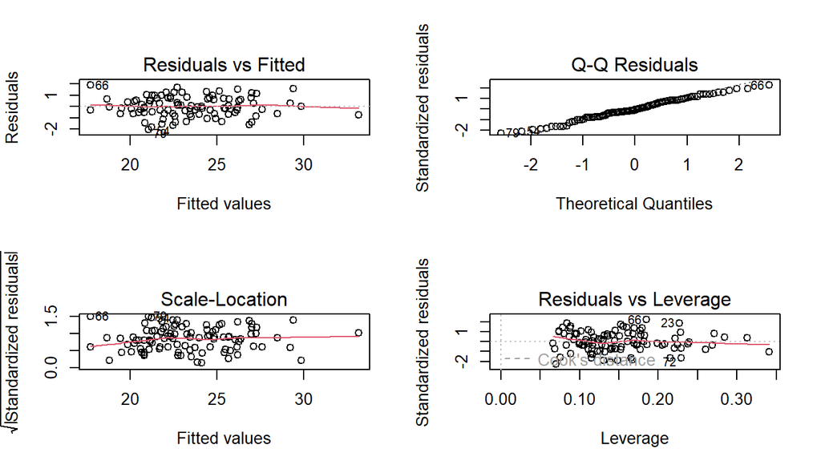

```r
# Gráficos diagnósticos
par(mfrow = c(2, 2))
plot(modelo_imc_final)
```

```r
par(mfrow = c(1, 1))
```

Se concluye que el modelo presenta problemas severos de multicolinealidad. Nuevamente informamos que como los datos representan medidas de perímetros y dimensiones corporales humanas (como el contorno de pecho, cintura y cadera), es esperable que estas variables estén fuertemente correlacionadas entre sí

9. Gráfica de influencia

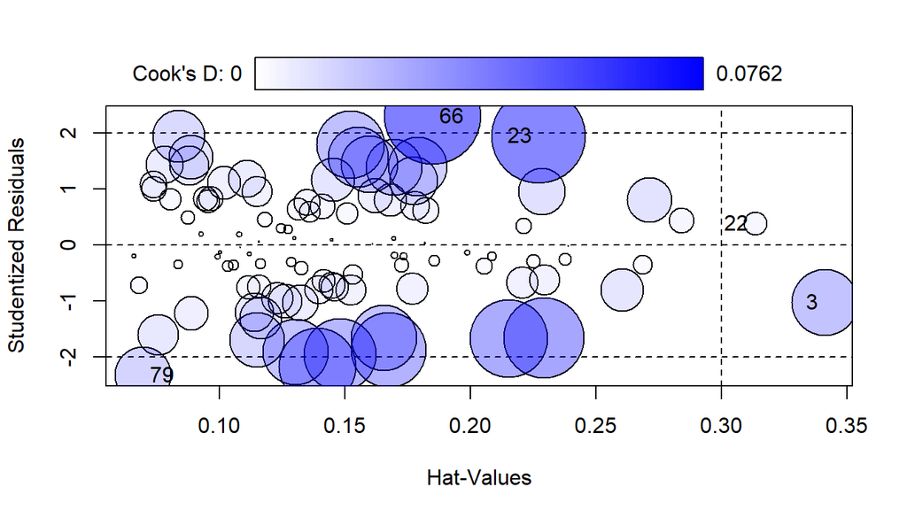

|  | StudRes | Hat | CookD |
| --- | --- | --- | --- |
| 3 | -1.0185640 | 0.34106475 | 0.035783934 |
| 22 | 0.3875414 | 0.31332050 | 0.004614701 |
| 23 | 1.9444862 | 0.22715647 | 0.071741473 |
| 66 | 2.2994859 | 0.18508790 | 0.076219323 |
| 79 | -2.3227616 | 0.06985549 | 0.025684595 |

```r
influencePlot(modelo_imc_final)
```

### Diagnósticos del modelo de EN (Pregunta 5)

```r
# Curva ROC del modelo final sobre datos de entrenamiento
modelo_en_final <- modelo_rfe_en$fit
probs_en <- predict(modelo_en_final, type = "response")
roc_en <- roc(respuesta_en, probs_en, quiet = TRUE)

cat(sprintf("AUC del modelo final (resustitución): %.4f\n", auc(roc_en)))
```

```
## AUC del modelo final (resustitución): 0.9640
```

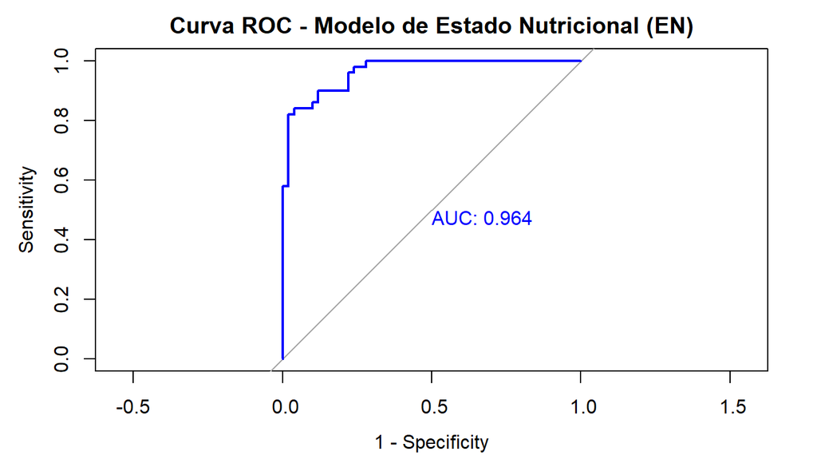

```r
# Gráfico de la curva ROC
plot(roc_en,
     main = "Curva ROC - Modelo de Estado Nutricional (EN)",
     col = "blue", lwd = 2, print.auc = TRUE, legacy.axes = TRUE)
```

```r
# Matriz de confusión
pred_clase <- ifelse(probs_en > 0.5,
                     levels(respuesta_en)[2],
                     levels(respuesta_en)[1])
pred_clase <- factor(pred_clase, levels = levels(respuesta_en))
cat("\nMatriz de confusión (punto de corte = 0.5):\n")
```

```
##
## Matriz de confusión (punto de corte = 0.5):
```

```r
mc_en <- confusionMatrix(pred_clase, respuesta_en)
print(mc_en)
```

```
## Confusion Matrix and Statistics
##
##               Reference
## Prediction     no.sobrepeso sobrepeso
##   no.sobrepeso           45         8
##   sobrepeso               5        42
##
##                Accuracy : 0.87
##                  95% CI : (0.788, 0.9289)
##     No Information Rate : 0.5
##     P-Value [Acc > NIR] : 6.565e-15
##
##                   Kappa : 0.74
##
##  Mcnemar's Test P-Value : 0.5791
##
##             Sensitivity : 0.9000
##             Specificity : 0.8400
##          Pos Pred Value : 0.8491
##          Neg Pred Value : 0.8936
##              Prevalence : 0.5000
##          Detection Rate : 0.4500
##    Detection Prevalence : 0.5300
##       Balanced Accuracy : 0.8700
##
##        'Positive' Class : no.sobrepeso
##
```

1. Relación lineal entre predictores y la respuesta transformada

```r
library(car)

# Extraer los nombres de las variables seleccionadas por RFE para EN
predictores_en_seleccionados <- predictors(modelo_rfe_en)
cat("Predictores seleccionados para EN:\n")
```

```
## Predictores seleccionados para EN:
```

```r
print(predictores_en_seleccionados)
```

```
## [1] "Knee.Girth"              "Bitrochanteric.diameter"
## [3] "Age"                     "Forearm.Girth"
## [5] "Thigh.Girth"             "Chest.depth"
```

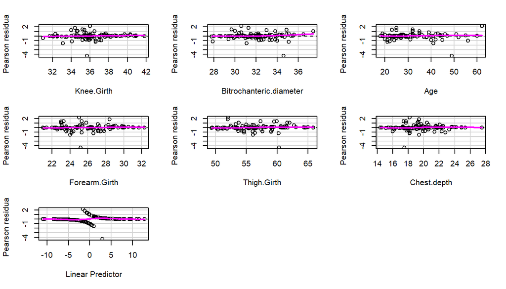

```
##                         Test stat Pr(>|Test stat|)
## Knee.Girth                 0.0001          0.99039
## Bitrochanteric.diameter    0.2956          0.58663
## Age                        0.0164          0.89818
## Forearm.Girth              2.7956          0.09452 .
## Thigh.Girth                3.9218          0.04766 *
## Chest.depth                2.0579          0.15142
## ---
## Signif. codes:  0 '***' 0.001 '**' 0.01 '*' 0.05 '.' 0.1 ' ' 1
```

```r
# Construir la fórmula dinámica para regresión logística
formula_en_nativa <- as.formula(paste("EN ~", paste(predictores_en_seleccionados, collapse = " + ")))

# Ajustar el modelo de forma nativa en R (asegurando family = binomial)
modelo_nativo_en <- glm(formula_en_nativa, data = muestra_total, family = binomial)

# Ejecutar residualPlots() sobre el modelo logístico nativo
residualPlots(modelo_nativo_en)
```

2. Residuos independientes entre sí

```r
durbinWatsonTest(modelo_en_final)
```

```
##  lag Autocorrelation D-W Statistic p-value
##    1       0.3647072      1.270245       0
##  Alternative hypothesis: rho != 0
```

Existe evidencia estadística suficiente (95% de confianza) para afirmar que no se cumple el supuesto de independencia de los residuos.

3. Multicolinealidad entre los predictores

```r
vif(modelo_en_final)
```

```
##              Knee.Girth Bitrochanteric.diameter                     Age
##                2.341118                2.780225                1.760005
##           Forearm.Girth             Thigh.Girth             Chest.depth
##                4.035558                5.763960                1.633013
```

El modelo de regresión logística presenta la menor multicolinealidad entre predictores comparándolo con los dos modelos anteriores. Únicamente dos de las variables pueden ser moderamente preocupantes “Forearm.Girth” y “Thigh.Girth” donde esta última supera el umbral de 5 para su factor de inflación de varianza.

4. Información incompleta

No se cumple con este supuesto dado que varias de las combinaciones entre predictores y variable de respuesta no presentan la cantidad suficiente de observaciones (10 a 15).

5. Separación perfecta

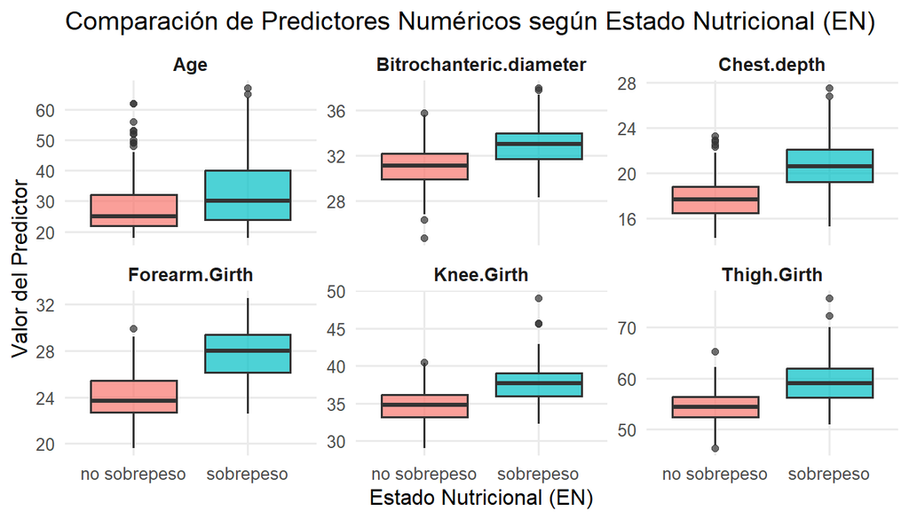

```r
library(ggplot2)
library(tidyr)
library(dplyr)

# Transformar los datos a formato largo

datos_largo <- datos |>
  pivot_longer(
    cols = c(Knee.Girth, Bitrochanteric.diameter, Age, Forearm.Girth, Thigh.Girth, Chest.depth),
    names_to = "Predictor",                           # Nombre de la nueva columna de etiquetas
    values_to = "Valor"                               # Nombre de la nueva columna con los valores numéricos
  )

# Generar la gráfica única con facetas
ggplot(datos_largo, aes(x = as.factor(EN), y = Valor, fill = as.factor(EN))) +
  geom_boxplot(alpha = 0.7, show.legend = FALSE) +
  facet_wrap(~ Predictor, scales = "free_y") +  # Crea un panel para cada predictor y libera la escala del eje Y
  labs(
    title = "Comparación de Predictores Numéricos según Estado Nutricional (EN)",
    x = "Estado Nutricional (EN)",
    y = "Valor del Predictor"
  ) +
  theme_minimal(base_size = 12) +
  theme(
    strip.text = element_text(face = "bold", size = 10), # Destaca los títulos de cada panel
    panel.grid.minor = element_blank()
  )
```

A partir de la inspección visual de los diagramas de caja generados para los predictores frente al estado nutricional (EN), se observa un solapamiento considerable en los rangos de distribución entre las clases de sobrepeso y no sobrepeso, en al menos 4 de los 6 predictores utilizados por el modelo. Esto confirma la ausencia de separación perfecta en los datos. Dicho comportamiento es estadísticamente favorable, ya que garantiza la estabilidad numérica del algoritmo de máxima verosimilitud, evita estimaciones de coeficientes infinitos y asegura que el modelo de regresión logística capture relaciones probabilísticas robustas.

6. Casos influyentes

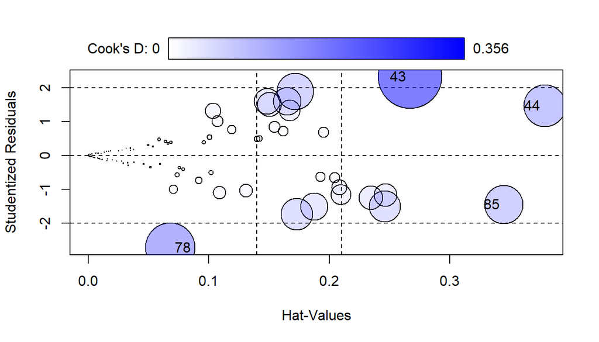

|  | StudRes | Hat | CookD |
| --- | --- | --- | --- |
| 43 | 2.325767 | 0.26720829 | 0.3556853 |
| 44 | 1.473639 | 0.37869198 | 0.1557111 |
| 78 | -2.720555 | 0.06817667 | 0.2144062 |
| 85 | -1.445821 | 0.34477870 | 0.1283554 |

```r
influencePlot(modelo_en_final)
```

# Conclusiones

**Modelo de Peso (Pregunta 3):** El modelo de regresión lineal múltiple para estimar el peso, evaluado con bootstrapping (999 repeticiones), presenta un R² de 0.9673, lo que indica que explica aproximadamente el 96.7% de la variabilidad del peso corporal. El RMSE de 2.31 kg representa el error promedio de predicción. Respecto a las condiciones del modelo, la prueba de Shapiro-Wilk no rechaza la normalidad de los residuos (p = 0.365), cumpliendo este supuesto. En cuanto a la multicolinealidad, 3 predictor(es) presenta(n) VIF > 5, lo que sugiere cierto grado de multicolinealidad que podría afectar la estabilidad de los coeficientes individuales, aunque no necesariamente la capacidad predictiva global del modelo. En conjunto, dado que el bootstrapping provee una estimación robusta y honesta del rendimiento, este modelo se considera **confiable y con alto poder predictivo** para estimar el peso corporal.

**Modelo de IMC (Pregunta 4):** El modelo de regresión lineal múltiple para predecir el IMC, evaluado con validación cruzada repetida (5 pliegues × 5 repeticiones), alcanza un R² de 0.8722 con 14 predictores seleccionados mediante RFE. El RMSE de 1.06 kg/m² indica el error típico de predicción. La prueba de Shapiro-Wilk no rechaza la normalidad de los residuos (p = 0.606). Respecto a la multicolinealidad, 8 de 14 predictores muestran VIF > 5, lo cual es razonable en un modelo con muchos predictores anatómicos correlacionados entre sí; la validación cruzada ya mitiga el impacto de esto en la estimación del rendimiento. Considerando que la validación cruzada repetida proporciona una estimación estable del error de generalización, este modelo se considera **confiable y con alto poder predictivo** para predecir el IMC.

**Modelo de EN (Pregunta 5):** El modelo de regresión logística múltiple para clasificar el estado nutricional, evaluado con LOOCV, presenta un AUC-ROC de 0.9088, una sensibilidad de 0.8 y una especificidad de 0.82, utilizando 6 predictores seleccionados por RFE. Un AUC superior a 0.9 indica una excelente capacidad de discriminación entre las categorías de estado nutricional. Dado que la validación LOOCV es la más conservadora posible (cada observación se predice usando un modelo entrenado sin ella), las métricas reportadas representan una estimación casi insesgada del rendimiento real. En conclusión, este modelo se considera **confiable y con alto poder predictivo** para clasificar el estado nutricional.

**Síntesis general:** Los tres modelos fueron evaluados con técnicas de remuestreo (bootstrapping, validación cruzada repetida y LOOCV) que minimizan el riesgo de sobreajuste y proporcionan estimaciones realistas del rendimiento sobre datos no vistos. Tras los análisis de confiabilidad y poder predictivo de cada uno de los modelos, se concluye que presentan problemas respecto a varias de las condiciones planteadas en el libro guía del curso, lo que sugiere que debemos tener especial cuidado a la hora de utilizar estos modelos para intentar predecir datos. Ningún modelo está exento de violar de forma parcial algunos supuestos clásicos de la regresión. El valor de este estudio radica precisamente en haber diagnosticado rigurosamente dichas desviaciones (como la linealidad, homocedasticidad, independencia y multicolinealidad), proporcionando un panorama transparente y fundamentado para la toma de decisiones basada en datos

# Referencias

Jara, J. L., & Köhler, J. (s. f.). Inferencia y modelos estadísticos [Perusall].

Heinz, G., Peterson, L. J., Johnson, R. W., & Kerk, C. J. (2003). Exploring Relationships in Body Dimensions. Journal Of Statistics Education, 11(2). https://doi.org/10.1080/10691898.2003.11910711